# Notebook

## Chapter 5.III K-Nearest Neighbors (KNN)

**K-Nearest Neighbors (KNN)** is a simple yet powerful and intuitive machine learning algorithm used for both **classification** and **regression** tasks.  
It is a **non-parametric**, **nonlinear**, and **instance-based learning** method, meaning that it makes **no assumptions about the underlying data distribution**.  
Instead, it relies directly on the training data to make predictions by measuring similarity between data points.

In KNN regression, the predicted value for a new input $x$ is obtained by averaging the responses of its $k$ nearest neighbors:

$$ \hat{f}_k(x) = \frac{1}{k} \sum_{i \in \mathcal{N}_k(x)} y_i $$

where $\mathcal{N}_k(x)$ denotes the set of indices corresponding to the $k$ nearest neighbors of $x$ in the training data.

The **distance metric** — most commonly the **Euclidean distance**, but also alternatives such as **Manhattan**, **Minkowski**, or **Mahalanobis distance** — is used to quantify the similarity between points.  
For example, when $k = 3$, the algorithm identifies the three nearest points to $x$ and predicts the target value by averaging their corresponding responses $y_i$.

KNN operates under the principle of **feature similarity**: if two data points are close in the feature space, their outputs are likely to be similar. Hence, KNN assigns a value (for regression) or a label (for classification) to a new observation by examining its local neighborhood.

### When to Use KNN

KNN performs well when:

- The dataset is **small to medium-sized** (since the algorithm scales poorly with very large datasets).
- There is **limited prior knowledge** about the data-generating process.
- The relationship between predictors and response is **nonlinear** or **complex**, making parametric models unsuitable.
- The data are **well-scaled and normalized**, ensuring that no feature dominates the distance computation.

It is often applied in:

- Image recognition and computer vision tasks.
- Recommendation systems (e.g., similarity-based retrieval).
- Medical diagnostics and pattern recognition.

### Key Considerations in KNN

1. **Choice of $K$ (Number of Neighbors)**  
   The parameter $k$ controls the trade-off between **bias and variance**:
   - A **small $k$** (e.g., $k=1$) can lead to **high variance** and **overfitting**, since predictions rely heavily on individual noisy data points.
   - A **large $k$** smooths the decision boundary, potentially causing **underfitting**.
   - A good rule of thumb is to use **cross-validation** to select $k$ that minimizes the prediction error.
2. **Distance Metric**  
   The choice of metric affects which points are considered neighbors:
   - **Euclidean distance** for continuous, well-scaled variables.
   - **Manhattan distance** for high-dimensional or sparse data.
   - **Mahalanobis distance** when features are correlated.
   - For categorical features, similarity measures like **Hamming distance** may be used.
3. **Feature Scaling**  
   Because KNN depends on distance calculations, **feature normalization (e.g., min–max or z-score scaling)** is essential.  
   Without scaling, features with large numeric ranges can dominate the distance metric.
4. **Computational Efficiency**  
   KNN is a **lazy learner**, meaning that no explicit model is trained; predictions are made at query time.  
   This leads to **high computational cost** for large datasets.  
   Efficient data structures such as **KD-trees**, **Ball trees**, or **approximate nearest neighbor (ANN)** algorithms can help accelerate neighbor searches.
5. **Imbalanced Data**  
   In classification tasks, if one class dominates the dataset, KNN may be biased toward that class.  
   Solutions include:
   - **Weighted KNN**, where neighbors closer to $x$ have higher influence.
   - **Resampling** or **SMOTE** to balance class distributions.

Advantages of KNN

- Simple to understand and implement.
- Naturally captures **nonlinear relationships**.
- No explicit training phase — the model is **ready after data collection**.
- Works well with **multi-modal data distributions**.

Limitations

- **Computationally expensive** for large datasets ($O(n)$ per query).
- **Sensitive to irrelevant or highly correlated features.**
- **Performance deteriorates** in high-dimensional spaces due to the **curse of dimensionality**.
- Requires **careful scaling** and **feature selection** for optimal results.

#### Example:

Use the K-Nearest Neighbors (KNN) method to build a predictive model for estimating the median value of owner-occupied homes (medv) using all available predictors in the dataset.

```r
#Use Mars to build a model to predict "house price" using othe varialbes in the data.

# Use the boston housing data
# Build a neural net model to predict "medv" using all other features
library(MASS)
library(tidyverse)
library(caret)


#There are 14 varables:  medv is the price of house (response)
data(Boston)
str(Boston)

set.seed(252)

index = createDataPartition(Boston$medv, p = 0.8, list = FALSE)
train.dat = Boston[index,]
test.dat =   Boston[-index,]
```

```
'data.frame':	506 obs. of  14 variables:
 $ crim   : num  0.00632 0.02731 0.02729 0.03237 0.06905 ...
 $ zn     : num  18 0 0 0 0 0 12.5 12.5 12.5 12.5 ...
 $ indus  : num  2.31 7.07 7.07 2.18 2.18 2.18 7.87 7.87 7.87 7.87 ...
 $ chas   : int  0 0 0 0 0 0 0 0 0 0 ...
 $ nox    : num  0.538 0.469 0.469 0.458 0.458 0.458 0.524 0.524 0.524 0.524 ...
 $ rm     : num  6.58 6.42 7.18 7 7.15 ...
 $ age    : num  65.2 78.9 61.1 45.8 54.2 58.7 66.6 96.1 100 85.9 ...
 $ dis    : num  4.09 4.97 4.97 6.06 6.06 ...
 $ rad    : int  1 2 2 3 3 3 5 5 5 5 ...
 $ tax    : num  296 242 242 222 222 222 311 311 311 311 ...
 $ ptratio: num  15.3 17.8 17.8 18.7 18.7 18.7 15.2 15.2 15.2 15.2 ...
 $ black  : num  397 397 393 395 397 ...
 $ lstat  : num  4.98 9.14 4.03 2.94 5.33 ...
 $ medv   : num  24 21.6 34.7 33.4 36.2 28.7 22.9 27.1 16.5 18.9 ...
```

4.7026936026936

6.71252159236349

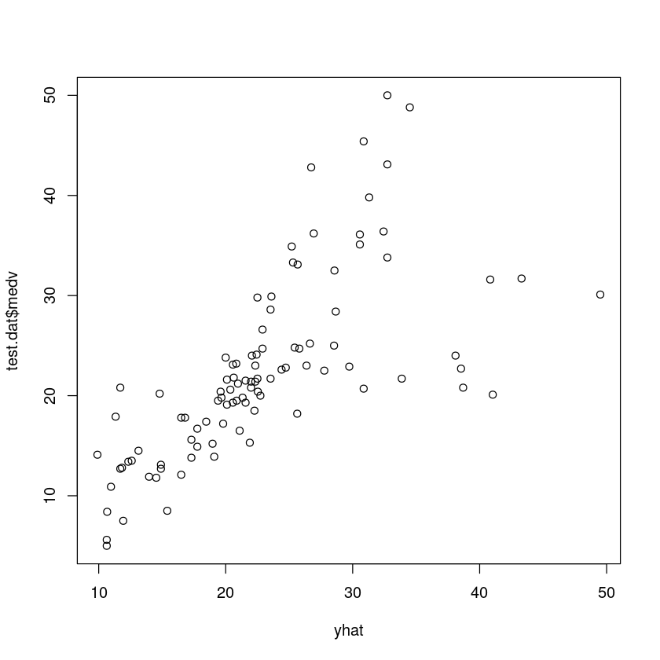

```r
#The predictor variables --> matrix
X = train.dat[, -14]
#medv of the train data
y = train.dat[, 14]

#KNN regression with k=7
knn.fit1 = knnreg(X, y, k= 3)
#knn.fit2 = knnreg(medv~., data=train.dat, k=7)

#Make prediction of the model on the testing data
#test.dat[,-14] : the predictors in the testing data
yhat = predict(knn.fit1,  test.dat[,-14])
plot(yhat,  test.dat$medv)

caret::MAE(test.dat$medv, yhat)
#RMSE on the testing data of the fitted model
caret::RMSE(test.dat$medv, yhat)

#
```

```r
# Model training using the caret package : train function
set.seed(295)

#Cross validation
cv.control =  trainControl(method = "cv",
                           number = 10)

#
# create a tuning grid
# hyper parameter:  k
hyper_grid = expand.grid(k = 1:10)

#train to find the optimal tuning parameters
knn.fit = train(medv ~ ., data = train.dat,  method = "knn",
                   trControl = cv.control,
                   trace = FALSE,
                   tuneGrid = hyper_grid
               #    preProc = c("center", "scale"),
               #    maxit = 500
                )

#The best tuning paramter
knn.fit$bestTune
```

A data.frame: 1 × 1

|  | k <int> |
| --- | --- |
| 3 | 3 |

```r
#KNN regression with k=3
knn.fit1 = knnreg(X, y, k= 3)
#knn.fit2 = knnreg(medv~., data=train.dat, k=7)
```

## Data Scaling

Before applying **K-Nearest Neighbors (KNN)**, it is essential to **preprocess the data** to ensure the algorithm performs effectively. This preprocessing typically includes handling **outliers**, **missing values**, and **feature scaling or normalization**. Because the KNN algorithm is **distance-based**, unscaled features can distort the notion of "closeness" between data points. For example, if one feature has a range from 0–10,000 (e.g., income) and another from 0–10 (e.g., education level), the distance measure will be dominated by the larger-scale feature unless proper scaling is applied.

#### Key Preprocessing Steps

1. **Handling Missing Values**  
   Missing values can bias distance computations or cause errors in training.  
   Common solutions include:
   - **Mean or median imputation** for continuous variables.
   - **Mode imputation** for categorical variables.
   - **KNN-based imputation**, where missing values are estimated using nearby points.
2. **Outlier Detection and Treatment**  
   Outliers can disproportionately influence distance-based methods.  
   Techniques such as **z-score filtering**, **IQR range filtering**, or **robust scaling** can be used to reduce their impact.
3. **Feature Scaling / Normalization**  
   Scaling ensures that all features contribute equally to distance computations.  
   Common approaches include:
   - **Min–Max Scaling:** rescales features to the range $[0, 1]$ $$ x' = \frac{x - x_{\min}}{x_{\max} - x_{\min}} $$
   - **Z-score Standardization:** centers data to mean $0$ and standard deviation $1$ $$ x' = \frac{x - \mu}{\sigma} $$
   - **Robust Scaling:** based on the median and interquartile range (IQR), effective when data contain outliers $$ x' = \frac{x - \text{median}(x)}{\text{IQR}(x)} $$
4. **Dimensionality Reduction (Optional)**  
   In high-dimensional spaces, distances between points become less meaningful — this is known as the **curse of dimensionality**.  
   Applying **Principal Component Analysis (PCA)** or **feature selection** can help reduce noise and improve KNN performance.

```r
#There are 14 varables:  medv is the price of house (response)
data(Boston)
#str(Boston)

set.seed(252)
#Run scale transformation on all variables
Boston.s =  Boston %>%  mutate_all(scale)

#keep the response in the orignal scale
Boston.s$medv = Boston$medv

index = createDataPartition(Boston.s$medv, p = 0.8, list = FALSE)
train.dat = Boston.s[index,]
test.dat =   Boston.s[-index,]

#The predictor variables --> matrix
X =  train.dat[, -14]
#medv of the train data
y =  train.dat[, 14]

#KNN regression with k=3
knn.fit2 = knnreg(X, y, k= 3)
```

2.44410774410774

3.56844412741186

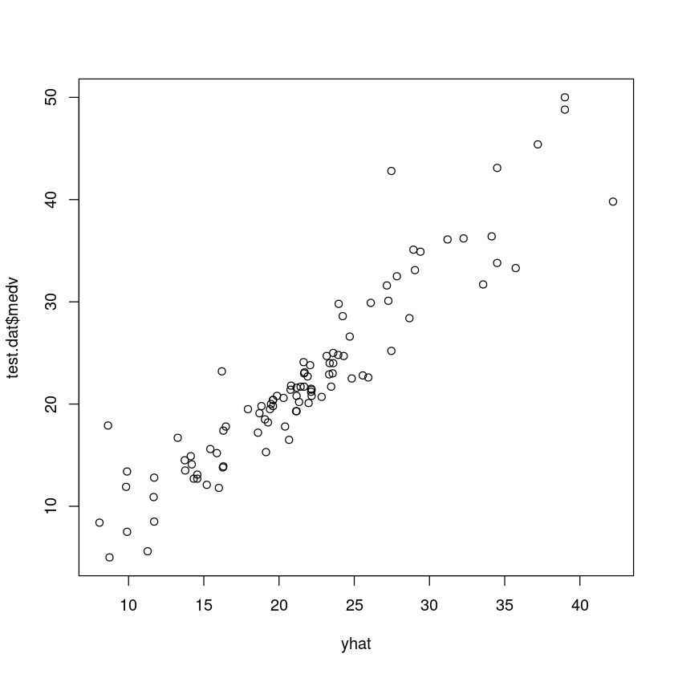

```r
#Make prediction on the test data
yhat = predict(knn.fit2,  test.dat[,-14])
plot(yhat,  test.dat$medv)

caret::MAE(test.dat$medv, yhat)
#RMSE on the testing data of the fitted model
caret::RMSE(test.dat$medv, yhat)
```

```r
# Possible dataset for your project:
# https://archive.ics.uci.edu
```

```
k-Nearest Neighbors

407 samples
 13 predictor

Pre-processing: centered (13), scaled (13)
Resampling: Cross-Validated (5 fold)
Summary of sample sizes: 326, 327, 325, 325, 325
Resampling results across tuning parameters:

  k   RMSE      Rsquared   MAE
   5  4.889399  0.7274210  3.066465
   7  5.039493  0.7158314  3.209879
   9  5.004474  0.7248319  3.237859
  11  5.061090  0.7217514  3.294035
  13  5.048776  0.7282458  3.318116
  15  5.106574  0.7224021  3.361500
  17  5.210340  0.7131217  3.409667
  19  5.245602  0.7163164  3.416673
  21  5.311270  0.7136367  3.452051
  23  5.400828  0.7086535  3.497796

RMSE was used to select the optimal model using the smallest value.
The final value used for the model was k = 5.
```

**RMSE**

4.01942505562397

**Rsquared**

0.823166722862174

**MAE**

2.70848484848485

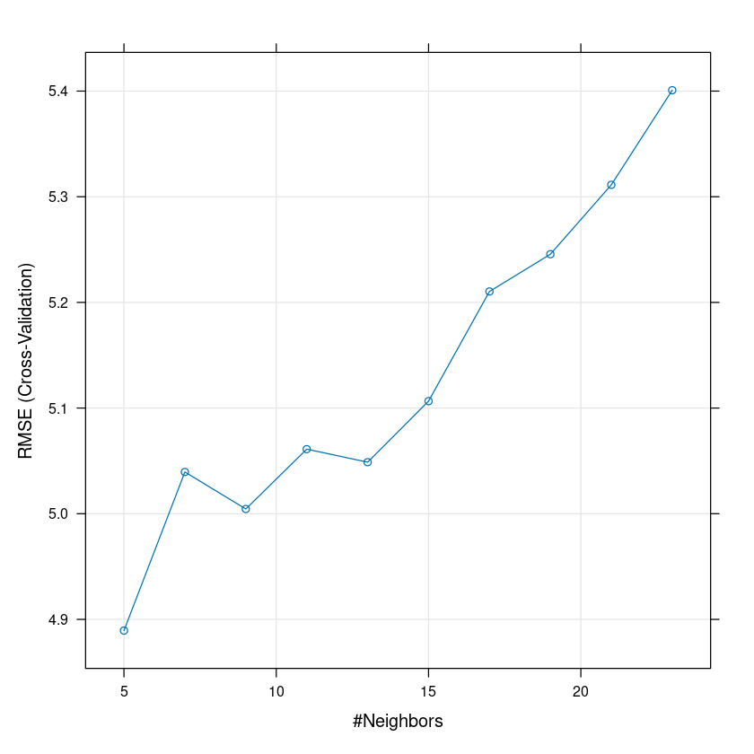

```r
# Define training control
ctrl = trainControl(method = "cv", number = 5)

# Fit KNN regression
knn.fit = train(medv ~ .,
                data = train.dat,
                method = "knn",
                trControl = ctrl,
                preProcess = c("center", "scale"),
                tuneLength = 10)

# Model summary
knn.fit

#This plot shows the cross-validated Root Mean Squared Error (RMSE) of a K-Nearest Neighbors (KNN) regression model as the number of neighbors (k) increases.
plot(knn.fit)

# Predict on test data
pred = predict(knn.fit, newdata = test.dat)

#postResample() is a utility function in the caret package that computes summary statistics comparing predicted values with observed (true) values for regression models.

postResample(pred, test.dat$medv)
```

```r
fit$method           # "knn"
fit$results          # performance across k values
fit$bestTune         # best value of k
fit$finalModel       # trained KNN model
fit$metric           # "Accuracy"
fit$resample         # results for each CV fold
fit$times            # training time
```

[output not shown]

| Component | Description |
| --- | --- |
| **`method`** | The modeling method used (e.g., `"lm"`, `"rf"`, `"knn"`, `"svmRadial"`, etc.). |
| **`modelInfo`** | A list with details about the model, including parameters, fitting function, and prediction method. |
| **`results`** | A data frame summarizing **performance metrics (e.g., RMSE, Accuracy, R²)** across all tuning parameter combinations. |
| **`bestTune`** | The **optimal tuning parameter(s)** chosen based on the resampling results (e.g., `k` for KNN, `mtry` for Random Forest). |
| **`finalModel`** | The **trained model** using the best tuning parameters and all the training data. You can use this for predictions directly. |
| **`resample`** | The performance results from each resample (e.g., each fold in cross-validation). Useful for diagnostic plots. |
| **`control`** | The control parameters used during training (e.g., resampling method, number of folds). |
| **`trainingData`** | A sample of the training data used (stored for internal checks). |
| **`pred`** | (Optional, if `savePredictions = TRUE`) Contains all resampled predictions for each parameter setting. Useful for plotting and comparison. |
| **`times`** | Timing information for model training — includes elapsed and CPU time. |
| **`call`** | The original call to `train()`. |
| **`metric`** | The metric used to select the best model (e.g., `"Accuracy"`, `"RMSE"`). |

| Operation | Description | Example |
| --- | --- | --- |
| **`plot(knn.fit)`** | Plot performance (e.g., Accuracy vs. k). | `plot(knn.fit)` |
| **`varImp(knn.fit)`** | Variable importance (if available for the method). | `varImp(knn.fit)` |
| **`ggplot(knn.fit)`** | ggplot2-based visualization of tuning results. | `ggplot(knn.fit)` |
| **`densityplot(knn.fit)`** | Visualize distribution of resampled accuracies. | `densityplot(knn.fit)` |
| **`dotplot(knn.fit)`** | Compare model performance across tuning parameters. | `dotplot(knn.fit)` |